# Question C

Feature Selection: 1) rimozione di attributi correlati tra loro (> di una certa soglia) 2) procedura stepAIC per determinare il miglior sottoinsieme di attributi, AIC è una stima della bontà del modello (considera il model fit e la semplicità del modello)

library

```r
#install.packages("caret", dep = TRUE)
library(skimr)
library(lattice)
library(ggplot2)
library(data.table)
library(caret)
library(glmnet)
```

```r
aida = fread("aida_preproc.csv")
```

```
|--------------------------------------------------|
|==================================================|
|--------------------------------------------------|
|==================================================|
```

```r
# Make the operator
'%!in%' <- function(x,y)!('%in%'(x,y))

# Add new empty column
aida$Failed <- NULL
# For each 'Legal status' which contains 'Active' substring fill in new column 'No' else 'Yes'
act_vector <- c('Active','Active (default of payments)','Active (receivership)')
aida[aida$Legal.status %in% act_vector,'Failed'] <- 0
aida[aida$Legal.status %!in% act_vector,'Failed'] <- 1

aida[is.na(aida$Failed), ]
```

| Year | Incorporation.year | Company.name | File | Tax.code.number | ATECO.2007code | Legal.form | Legal.status | Province | Comune.ISTAT.code | Region | Banks/turnover | Cash.Flowth | Cost.of.debit | Current.liabilities/Tot.ass | Current.ratio | Debt/EBITDA.ratio | Debt/equity.ratio | EBITDA/Vendite | EBITDAth | Interest/Turnover | Leverage | Liquidity.ratio | Net.financial.positionth | Net.working.capitalth | Number.of.employees | Profit.(loss)th | ROA | ROE | ROI | … |
| --- | --- | --- | --- | --- | --- | --- | --- | --- | --- | --- | --- | --- | --- | --- | --- | --- | --- | --- | --- | --- | --- | --- | --- | --- | --- | --- | --- | --- | --- | --- |

```r
aida$Failed <- as.factor(aida$Failed)

drops <- c('Company.name','File','Tax.code.number','Legal.form','Legal.status','Comune.ISTAT.code','Region','Province')
aida <- subset(aida, select = -c(Company.name,ATECO.2007code,File,Tax.code.number,Legal.form,Legal.status,Comune.ISTAT.code,Region,Province))
```

```r
#create subsample of the dataset
sample = rbinom(nrow(aida), 1, .5)
data = aida[sample==1,]

#data = aida[aida$Year==2016, ]

#dummies <- dummyVars( ~ ., data = data)
#head(predict(dummies, newdata = data))
#skim(data)
```

1. Un problema dei modelli lineari è l’alta correlazione tra le variabili indipendenti, prima di costruire il regresore logistico si cerca di escludere le variabili con correlazione > di una certa soglia
- In caso di correlazione tra due variabili, si elimina quella con VIF (Variance Inflation Factor) maggiore
- In alternativa, il metodo findCorrelation della libreria caret, restituisce direttamente le variabili da escludere sulla base della mean absolute correlation (“https://www.rdocumentation.org/packages/caret/versions/6.0-88/topics/findCorrelation”), oltre che le coppie di variabili che superano il cutoff

```r
corr.matrix=cor(subset(na.omit(aida), select = -c(Failed)))
#corr.matrix[abs(corr.matrix) < 0.8] = NA
#View(corr.matrix)
to.remove = findCorrelation(corr.matrix, cutoff = .8, verbose = TRUE, names=TRUE)
```

```
Compare row 19  and column  21 with corr  0.859
  Means:  0.153 vs 0.106 so flagging column 19
Compare row 17  and column  15 with corr  0.812
  Means:  0.154 vs 0.102 so flagging column 17
Compare row 4  and column  18 with corr  0.902
  Means:  0.124 vs 0.099 so flagging column 4
Compare row 15  and column  16 with corr  0.916
  Means:  0.092 vs 0.098 so flagging column 16
Compare row 14  and column  7 with corr  0.811
  Means:  0.132 vs 0.098 so flagging column 14
All correlations <= 0.8
```

```r
to.remove
```

[output not shown]

```r
colnames(data)
```

```
 [1] "Year"                          "Incorporation.year"            "Banks/turnover"                "Cost.of.debit"
 [5] "Current.liabilities/Tot.ass"   "Current.ratio"                 "Debt/EBITDA.ratio"             "Debt/equity.ratio"
 [9] "EBITDA/Vendite"                "EBITDAth"                      "Interest/Turnover"             "Leverage"
[13] "Liquidity.ratio"               "Net.financial.positionth"      "Net.working.capitalth"         "Number.of.employees"
[17] "Profit.(loss)th"               "ROA"                           "ROE"                           "ROI"
[21] "ROS"                           "Solvency.ratio"                "Total.assets.turnover.(times)" "Total.assetsth"
[25] "Failed"
```

```r
cat(colnames(data)[19], "-", colnames(data)[21], "\n")
```

```
ROE - ROS
```

```r
cat(colnames(data)[17], "-", colnames(data)[15], "\n")
```

```
Profit.(loss)th - Net.working.capitalth
```

```r
cat(colnames(data)[4], "-", colnames(data)[18], "\n")
```

```
Cost.of.debit - ROA
```

```r
cat(colnames(data)[15], "-", colnames(data)[16], "\n")
```

```
Net.working.capitalth - Number.of.employees
```

```r
cat(colnames(data)[14], "-", colnames(data)[7])
```

```
Net.financial.positionth - Debt/EBITDA.ratio
```

Si guarda al valore di VIF, le variabili con valore alto devono essere rimosse

```r
sort(vif(lr.fit))
```

[output not shown]

Data Partitioning

```r
set.seed(42)
trainIndex <- createDataPartition(data$Failed, p = .7,
                                  list = FALSE,
                                  times = 1)

aidaTrain <- data[ trainIndex,]
aidaTest  <- data[-trainIndex,]

aidaTrain <- na.omit(aidaTrain)
aidaTest <- na.omit(aidaTest)

aidaTrain <- subset(aidaTrain, select = -c(Year))

table(aidaTrain$Failed)
```

```
     0      1
168331  50238
```

```r
down.aidaTrain <- downSample(x = aidaTrain, y = aidaTrain$Failed)
down.aidaTrain <- subset(down.aidaTrain, select = -c(Class))
table(down.aidaTrain$Failed)
```

```
    0     1
50238 50238
```

```r
over.aidaTrain <- upSample(x = aidaTrain, y = aidaTrain$Failed)
over.aidaTrain <- subset(over.aidaTrain, select = -c(Class))
table(over.aidaTrain$Failed)
```

```
     0      1
168331 168331
```

Logistic regression eliminando le variabili altamente correlate

```r
# resampling method
noresampling = trainControl(method="none")

lr.fit = train(Failed ~ ., data = subset(aidaTrain, select=-c(ROS, Net.working.capitalth, ROA, Net.financial.positionth)),
               method = "glm", trControl=noresampling,
               # pass-trough options
               family=binomial(logit))
lr.fit
```

```
Generalized Linear Model

218569 samples
    19 predictor
     2 classes: '0', '1'

No pre-processing
Resampling: None
```

```r
summary(lr.fit)
```

```
Call:
NULL

Deviance Residuals:
    Min       1Q   Median       3Q      Max
-3.7826  -0.7246  -0.5560  -0.3304   3.0942

Coefficients:
                                        Estimate Std. Error z value Pr(>|z|)
(Intercept)                           -4.878e+00  8.696e-01  -5.610 2.03e-08 ***
Incorporation.year                     6.600e-04  4.338e-04   1.521 0.128178
`\\`Banks/turnover\\``                 5.732e-03  4.859e-04  11.795  < 2e-16 ***
Cost.of.debit                          5.784e-02  1.733e-03  33.378  < 2e-16 ***
`\\`Current.liabilities/Tot.ass\\``    2.048e+00  3.382e-02  60.556  < 2e-16 ***
Current.ratio                          2.285e-01  9.759e-03  23.410  < 2e-16 ***
`\\`Debt/EBITDA.ratio\\``             -1.971e-04  1.641e-04  -1.201 0.229903
`\\`Debt/equity.ratio\\``              9.240e-03  7.209e-04  12.818  < 2e-16 ***
`\\`EBITDA/Vendite\\``                -9.863e-04  7.665e-04  -1.287 0.198192
EBITDAth                              -3.698e-07  1.618e-06  -0.229 0.819215
`\\`Interest/Turnover\\``              1.711e-01  5.909e-03  28.950  < 2e-16 ***
Leverage                              -5.205e-04  1.333e-04  -3.904 9.48e-05 ***
Liquidity.ratio                       -7.772e-02  1.043e-02  -7.453 9.14e-14 ***
Number.of.employees                   -2.427e-04  7.158e-05  -3.391 0.000696 ***
`\\`Profit.(loss)th\\``               -6.836e-06  2.453e-06  -2.786 0.005330 **
ROE                                   -4.889e-03  2.344e-04 -20.855  < 2e-16 ***
ROI                                   -1.701e-02  7.916e-04 -21.482  < 2e-16 ***
Solvency.ratio                        -1.769e-02  3.986e-04 -44.367  < 2e-16 ***
`\\`Total.assets.turnover.(times)\\``  6.330e-02  9.173e-03   6.901 5.18e-12 ***
Total.assetsth                         1.102e-07  1.657e-07   0.665 0.506074
---
Signif. codes:  0 ‘***’ 0.001 ‘**’ 0.01 ‘*’ 0.05 ‘.’ 0.1 ‘ ’ 1

(Dispersion parameter for binomial family taken to be 1)

    Null deviance: 235659  on 218568  degrees of freedom
Residual deviance: 213099  on 218549  degrees of freedom
AIC: 213139

Number of Fisher Scoring iterations: 5
```

```r
# predicted confidence on validation set
lr.pred = predict(lr.fit, newdata = aidaTest, type="raw")
lr.prob = predict(lr.fit, newdata = aidaTest, type="prob") # as predict_proba in scikit-learn
lr.pconf = lr.prob[,2]
# built-in metrics
confusionMatrix(lr.pred, aidaTest$Failed, positive="1", mode = "prec_recall")
```

```
Confusion Matrix and Statistics

          Reference
Prediction     0     1
         0 70122 18787
         1  2182  2700

               Accuracy : 0.7764
                 95% CI : (0.7737, 0.7791)
    No Information Rate : 0.7709
    P-Value [Acc > NIR] : 2.769e-05

                  Kappa : 0.1311

 Mcnemar's Test P-Value : < 2.2e-16

              Precision : 0.55305
                 Recall : 0.12566
                     F1 : 0.20479
             Prevalence : 0.22909
         Detection Rate : 0.02879
   Detection Prevalence : 0.05205
      Balanced Accuracy : 0.54774

       'Positive' Class : 1
```

2. Variable selection usando la procedura stepAIC su tre training set differenti (originale, bilanciato con undersampling, bilanciato con oversampling)

Logistic regression con trainingset originale (leggermente sbilanciato)

```r
# resampling method
noresampling = trainControl(method="none")

lr.fit = train(Failed ~ ., data = aidaTrain,
               method = "glmStepAIC", trControl=noresampling,
               # pass-trough options
               family=binomial(logit))
```

```
Start:  AIC=212960.4
.outcome ~ Incorporation.year + `\`Banks/turnover\`` + Cost.of.debit +
    `\`Current.liabilities/Tot.ass\`` + Current.ratio + `\`Debt/EBITDA.ratio\`` +
    `\`Debt/equity.ratio\`` + `\`EBITDA/Vendite\`` + EBITDAth +
    `\`Interest/Turnover\`` + Leverage + Liquidity.ratio + Net.financial.positionth +
    Net.working.capitalth + Number.of.employees + `\`Profit.(loss)th\`` +
    ROA + ROE + ROI + ROS + Solvency.ratio + `\`Total.assets.turnover.(times)\`` +
    Total.assetsth

                                        Df Deviance    AIC
- Total.assetsth                         1   212912 212958
- EBITDAth                               1   212913 212959
- Incorporation.year                     1   212913 212959
- `\\`Debt/EBITDA.ratio\\``              1   212913 212959
- Net.financial.positionth               1   212914 212960
<none>                                       212912 212960
- Net.working.capitalth                  1   212920 212966
- `\\`Profit.(loss)th\\``                1   212926 212972
- Leverage                               1   212928 212974
- Number.of.employees                    1   212929 212975
- `\\`Total.assets.turnover.(times)\\``  1   212943 212989
- ROA                                    1   212944 212990
- `\\`EBITDA/Vendite\\``                 1   212948 212994
- Liquidity.ratio                        1   212982 213028
- `\\`Banks/turnover\\``                 1   213050 213096
- ROS                                    1   213084 213130
- ROI                                    1   213098 213144
- `\\`Debt/equity.ratio\\``              1   213124 213170
- ROE                                    1   213336 213382
- Current.ratio                          1   213492 213538
- `\\`Interest/Turnover\\``              1   213798 213844
- Cost.of.debit                          1   213982 214028
- Solvency.ratio                         1   214995 215041
- `\\`Current.liabilities/Tot.ass\\``    1   216986 217032

Step:  AIC=212958.4
.outcome ~ Incorporation.year + `\`Banks/turnover\`` + Cost.of.debit +
    `\`Current.liabilities/Tot.ass\`` + Current.ratio + `\`Debt/EBITDA.ratio\`` +
    `\`Debt/equity.ratio\`` + `\`EBITDA/Vendite\`` + EBITDAth +
    `\`Interest/Turnover\`` + Leverage + Liquidity.ratio + Net.financial.positionth +
```

[output cut: 111 more lines]

```
- ROI                                    1   213099 213137
- `\\`Debt/equity.ratio\\``              1   213125 213163
- ROE                                    1   213338 213376
- Current.ratio                          1   213493 213531
- `\\`Interest/Turnover\\``              1   213801 213839
- Cost.of.debit                          1   213986 214024
- Solvency.ratio                         1   215073 215111
- `\\`Current.liabilities/Tot.ass\\``    1   216987 217025

Step:  AIC=212953.5
.outcome ~ `\`Banks/turnover\`` + Cost.of.debit + `\`Current.liabilities/Tot.ass\`` +
    Current.ratio + `\`Debt/equity.ratio\`` + `\`EBITDA/Vendite\`` +
    `\`Interest/Turnover\`` + Leverage + Liquidity.ratio + Net.working.capitalth +
    Number.of.employees + `\`Profit.(loss)th\`` + ROA + ROE +
    ROI + ROS + Solvency.ratio + `\`Total.assets.turnover.(times)\``
```

```
                                        Df Deviance    AIC
<none>                                       212915 212953
- Net.working.capitalth                  1   212929 212965
- `\\`Profit.(loss)th\\``                1   212930 212966
- Leverage                               1   212931 212967
- Number.of.employees                    1   212945 212981
- `\\`Total.assets.turnover.(times)\\``  1   212947 212983
- ROA                                    1   212947 212983
- `\\`EBITDA/Vendite\\``                 1   212953 212989
- Liquidity.ratio                        1   212984 213020
- `\\`Banks/turnover\\``                 1   213051 213087
- ROS                                    1   213090 213126
- ROI                                    1   213100 213136
- `\\`Debt/equity.ratio\\``              1   213126 213162
- ROE                                    1   213339 213375
- Current.ratio                          1   213493 213529
- `\\`Interest/Turnover\\``              1   213803 213839
- Cost.of.debit                          1   213987 214023
- Solvency.ratio                         1   215078 215114
- `\\`Current.liabilities/Tot.ass\\``    1   216989 217025
```

```r
lr.fit
```

```
Generalized Linear Model with Stepwise Feature Selection

218569 samples
    23 predictor
     2 classes: '0', '1'

No pre-processing
Resampling: None
```

```r
summary(lr.fit)
```

```
Call:
NULL

Deviance Residuals:
    Min       1Q   Median       3Q      Max
-3.7599  -0.7237  -0.5557  -0.3271   3.1253

Coefficients:
                                        Estimate Std. Error z value Pr(>|z|)
(Intercept)                           -3.619e+00  4.334e-02 -83.500  < 2e-16 ***
`\\`Banks/turnover\\``                 5.714e-03  4.868e-04  11.736  < 2e-16 ***
Cost.of.debit                          5.739e-02  1.739e-03  33.001  < 2e-16 ***
`\\`Current.liabilities/Tot.ass\\``    2.093e+00  3.403e-02  61.516  < 2e-16 ***
Current.ratio                          2.461e-01  9.832e-03  25.032  < 2e-16 ***
`\\`Debt/equity.ratio\\``              9.135e-03  7.203e-04  12.682  < 2e-16 ***
`\\`EBITDA/Vendite\\``                 5.638e-03  9.111e-04   6.188 6.09e-10 ***
`\\`Interest/Turnover\\``              1.730e-01  5.932e-03  29.155  < 2e-16 ***
Leverage                              -5.038e-04  1.331e-04  -3.784 0.000154 ***
Liquidity.ratio                       -8.671e-02  1.043e-02  -8.311  < 2e-16 ***
Net.working.capitalth                 -1.004e-06  2.143e-07  -4.686 2.78e-06 ***
Number.of.employees                   -2.894e-04  6.206e-05  -4.662 3.13e-06 ***
`\\`Profit.(loss)th\\``               -9.263e-06  2.495e-06  -3.713 0.000205 ***
ROA                                    1.590e-02  2.822e-03   5.632 1.78e-08 ***
ROE                                   -4.833e-03  2.354e-04 -20.533  < 2e-16 ***
ROI                                   -1.689e-02  1.249e-03 -13.530  < 2e-16 ***
ROS                                   -2.027e-02  1.521e-03 -13.332  < 2e-16 ***
Solvency.ratio                        -1.848e-02  4.046e-04 -45.670  < 2e-16 ***
`\\`Total.assets.turnover.(times)\\``  5.299e-02  9.423e-03   5.624 1.87e-08 ***
---
Signif. codes:  0 ‘***’ 0.001 ‘**’ 0.01 ‘*’ 0.05 ‘.’ 0.1 ‘ ’ 1

(Dispersion parameter for binomial family taken to be 1)

    Null deviance: 235659  on 218568  degrees of freedom
Residual deviance: 212915  on 218550  degrees of freedom
AIC: 212953

Number of Fisher Scoring iterations: 5
```

```r
# predicted confidence on validation set
lr.pred = predict(lr.fit, newdata = aidaTest, type="raw")
lr.prob = predict(lr.fit, newdata = aidaTest, type="prob") # as predict_proba in scikit-learn
lr.pconf = lr.prob[,2]
# built-in metrics
confusionMatrix(lr.pred, aidaTest$Failed, positive="1", mode = "prec_recall")
```

```
Confusion Matrix and Statistics

          Reference
Prediction     0     1
         0 70125 18770
         1  2179  2717

               Accuracy : 0.7766
                 95% CI : (0.774, 0.7793)
    No Information Rate : 0.7709
    P-Value [Acc > NIR] : 1.407e-05

                  Kappa : 0.1322

 Mcnemar's Test P-Value : < 2.2e-16

              Precision : 0.55494
                 Recall : 0.12645
                     F1 : 0.20597
             Prevalence : 0.22909
         Detection Rate : 0.02897
   Detection Prevalence : 0.05220
      Balanced Accuracy : 0.54816

       'Positive' Class : 1
```

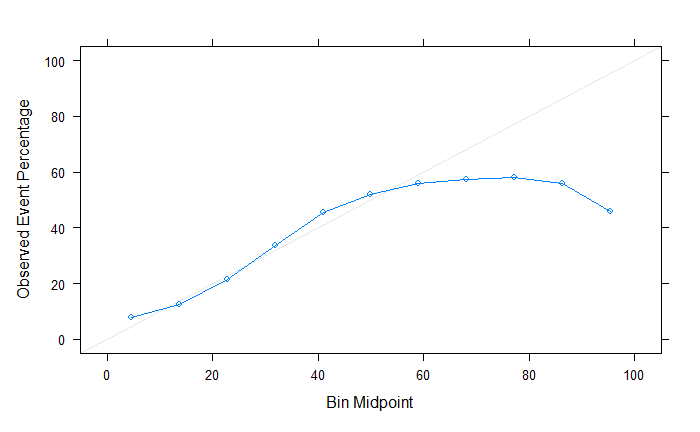

```r
# calibration plot
cal_data = calibration(aidaTest$Failed ~ lr.pconf, class="1")
xyplot(cal_data)
```

Logistic regression con training set bilanciato con random undersampling

```r
# resampling method
noresampling = trainControl(method="none")

lr.fit = train(Failed ~ ., data = down.aidaTrain,
               method = "glmStepAIC", trControl=noresampling,
               family=binomial(logit))
```

```
Start:  AIC=124592.5
.outcome ~ Incorporation.year + `\`Banks/turnover\`` + Cost.of.debit +
    `\`Current.liabilities/Tot.ass\`` + Current.ratio + `\`Debt/EBITDA.ratio\`` +
    `\`Debt/equity.ratio\`` + `\`EBITDA/Vendite\`` + EBITDAth +
    `\`Interest/Turnover\`` + Leverage + Liquidity.ratio + Net.financial.positionth +
    Net.working.capitalth + Number.of.employees + `\`Profit.(loss)th\`` +
    ROA + ROE + ROI + ROS + Solvency.ratio + `\`Total.assets.turnover.(times)\`` +
    Total.assetsth

                                        Df Deviance    AIC
- `\\`Debt/EBITDA.ratio\\``              1   124545 124591
<none>                                       124544 124592
- `\\`Total.assets.turnover.(times)\\``  1   124547 124593
- `\\`Profit.(loss)th\\``                1   124547 124593
- Total.assetsth                         1   124548 124594
- EBITDAth                               1   124555 124601
- Leverage                               1   124556 124602
- Incorporation.year                     1   124559 124605
- `\\`Banks/turnover\\``                 1   124561 124607
- Number.of.employees                    1   124563 124609
- Net.financial.positionth               1   124564 124610
- ROA                                    1   124565 124611
- Liquidity.ratio                        1   124567 124613
- `\\`EBITDA/Vendite\\``                 1   124580 124626
- Net.working.capitalth                  1   124581 124627
- ROS                                    1   124662 124708
- ROI                                    1   124663 124709
- `\\`Debt/equity.ratio\\``              1   124733 124779
- ROE                                    1   124806 124852
- Current.ratio                          1   124922 124968
- Cost.of.debit                          1   125074 125120
- `\\`Interest/Turnover\\``              1   125297 125343
- Solvency.ratio                         1   125799 125845
- `\\`Current.liabilities/Tot.ass\\``    1   127225 127271

Step:  AIC=124590.7
.outcome ~ Incorporation.year + `\`Banks/turnover\`` + Cost.of.debit +
    `\`Current.liabilities/Tot.ass\`` + Current.ratio + `\`Debt/equity.ratio\`` +
    `\`EBITDA/Vendite\`` + EBITDAth + `\`Interest/Turnover\`` +
    Leverage + Liquidity.ratio + Net.financial.positionth + Net.working.capitalth +
```

[output cut: 13 more lines]

```
- Number.of.employees                    1   124563 124607
- Net.financial.positionth               1   124564 124608
- ROA                                    1   124565 124609
- Liquidity.ratio                        1   124567 124611
- `\\`EBITDA/Vendite\\``                 1   124580 124624
- Net.working.capitalth                  1   124581 124625
- ROS                                    1   124663 124707
- ROI                                    1   124663 124707
- `\\`Debt/equity.ratio\\``              1   124734 124778
- ROE                                    1   124806 124850
- Current.ratio                          1   124922 124966
- Cost.of.debit                          1   125074 125118
- `\\`Interest/Turnover\\``              1   125297 125341
- Solvency.ratio                         1   125801 125845
- `\\`Current.liabilities/Tot.ass\\``    1   127226 127270
```

```r
lr.fit
```

[output not shown]

```r
best.formula = formula(lr.fit)
summary(lr.fit)
```

```
Call:
NULL

Deviance Residuals:
    Min       1Q   Median       3Q      Max
-4.1906  -1.0384  -0.0055   1.0563   3.2824

Coefficients:
                                        Estimate Std. Error z value Pr(>|z|)
(Intercept)                           -6.631e+00  1.115e+00  -5.949 2.70e-09 ***
Incorporation.year                     2.133e-03  5.563e-04   3.835 0.000126 ***
`\\`Banks/turnover\\``                 2.516e-03  6.171e-04   4.076 4.57e-05 ***
Cost.of.debit                          5.123e-02  2.235e-03  22.921  < 2e-16 ***
`\\`Current.liabilities/Tot.ass\\``    2.076e+00  4.117e-02  50.421  < 2e-16 ***
Current.ratio                          2.374e-01  1.220e-02  19.457  < 2e-16 ***
`\\`Debt/equity.ratio\\``              1.327e-02  1.105e-03  12.003  < 2e-16 ***
`\\`EBITDA/Vendite\\``                 6.790e-03  1.152e-03   5.892 3.83e-09 ***
EBITDAth                              -1.122e-05  3.451e-06  -3.252 0.001147 **
`\\`Interest/Turnover\\``              2.226e-01  8.348e-03  26.658  < 2e-16 ***
Leverage                              -5.770e-04  1.637e-04  -3.524 0.000425 ***
Liquidity.ratio                       -6.093e-02  1.286e-02  -4.739 2.14e-06 ***
Net.financial.positionth               5.979e-06  1.409e-06   4.243 2.21e-05 ***
Net.working.capitalth                 -5.895e-06  1.201e-06  -4.907 9.26e-07 ***
Number.of.employees                   -3.577e-04  9.222e-05  -3.879 0.000105 ***
`\\`Profit.(loss)th\\``               -8.510e-06  6.157e-06  -1.382 0.166927
ROA                                    1.526e-02  3.408e-03   4.478 7.54e-06 ***
ROE                                   -4.937e-03  3.094e-04 -15.955  < 2e-16 ***
ROI                                   -1.692e-02  1.561e-03 -10.841  < 2e-16 ***
ROS                                   -2.104e-02  1.957e-03 -10.753  < 2e-16 ***
Solvency.ratio                        -1.763e-02  5.021e-04 -35.122  < 2e-16 ***
`\\`Total.assets.turnover.(times)\\``  1.944e-02  1.164e-02   1.671 0.094789 .
Total.assetsth                         6.458e-07  3.205e-07   2.015 0.043939 *
---
Signif. codes:  0 ‘***’ 0.001 ‘**’ 0.01 ‘*’ 0.05 ‘.’ 0.1 ‘ ’ 1

(Dispersion parameter for binomial family taken to be 1)

    Null deviance: 139289  on 100475  degrees of freedom
Residual deviance: 124545  on 100453  degrees of freedom
AIC: 124591

Number of Fisher Scoring iterations: 5
```

```r
# predicted confidence on validation set
lr.pred = predict(lr.fit, newdata = aidaTest, type="raw")
lr.prob = predict(lr.fit, newdata = aidaTest, type="prob") # as predict_proba in scikit-learn
lr.pconf = lr.prob[,2]
# built-in metrics
confusionMatrix(lr.pred, aidaTest$Failed, positive="1", mode = "prec_recall")
```

```
Confusion Matrix and Statistics

          Reference
Prediction     0     1
         0 49443  7651
         1 22861 13836

               Accuracy : 0.6747
                 95% CI : (0.6717, 0.6777)
    No Information Rate : 0.7709
    P-Value [Acc > NIR] : 1

                  Kappa : 0.2625

 Mcnemar's Test P-Value : <2e-16

              Precision : 0.3770
                 Recall : 0.6439
                     F1 : 0.4756
             Prevalence : 0.2291
         Detection Rate : 0.1475
   Detection Prevalence : 0.3913
      Balanced Accuracy : 0.6639

       'Positive' Class : 1
```

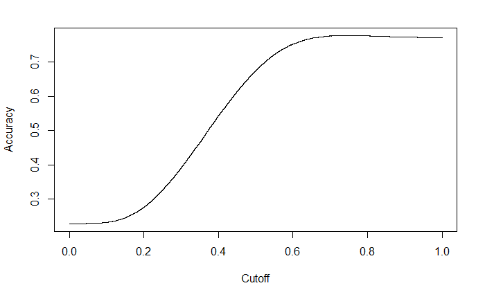

```r
# using ROCR for metrics at cutoff
library(ROCR)
lr.prediction = prediction(lr.pconf, aidaTest$Failed)
# acc at cutoff
lr.acc = performance(lr.prediction, "acc"); plot(lr.acc)
```

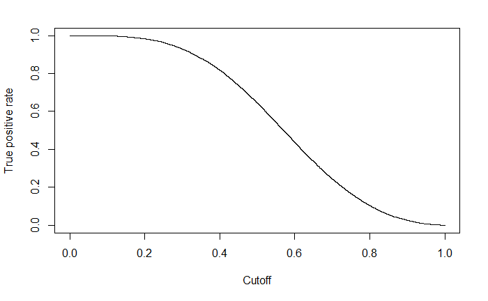

```r
# tpr (recall) at cutoff
lr.tpr = performance(lr.prediction, "tpr"); plot(lr.tpr)
```

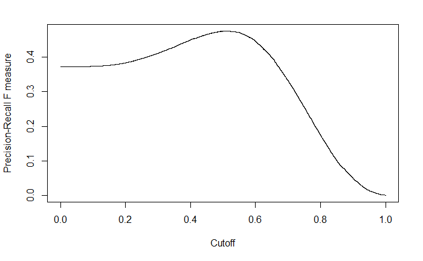

```r
# f1 at cutoff
lr.f1 = performance(lr.prediction, "f"); plot(lr.f1)
```

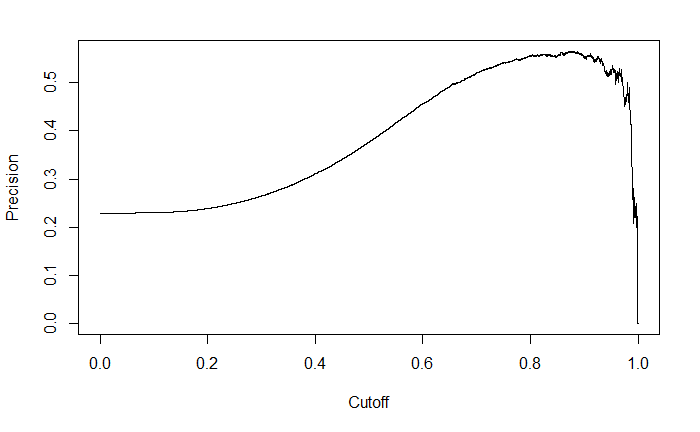

```r
# precision at cutoff
lr.prec = performance(lr.prediction, "prec"); plot(lr.prec)
```

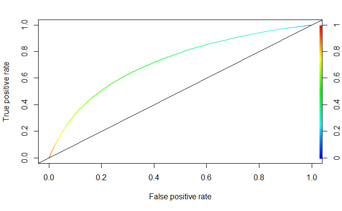

```r
# roc curve
lr.roc = performance(lr.prediction, "tpr", "fpr")
plot(lr.roc, colorize=T); abline(a=0, b= 1)
```

```r
# AUC: performance returns an object whose members (called 'slots') are accessed with '@'
o = performance(lr.prediction, "auc")
o@y.values[[1]]
```

```
[1] 0.7177129
```

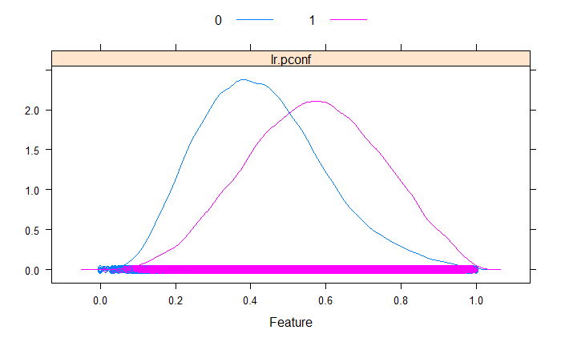

```r
featurePlot(x=data.frame(lr.pconf), y=aidaTest$Failed, plot='density', auto.key = list(columns = 2))
```

Cambio del decision threshold

```r
cutoff = 0.3
lr.pred.cutoff = factor(ifelse(lr.pconf>=cutoff, 1, 0), levels=levels(aidaTest$Failed))
confusionMatrix(lr.pred.cutoff, aidaTest$Failed, positive="1", mode = "prec_recall")
```

[output not shown]

Logistic regression con training set bilanciato con random oversampling

```r
# resampling method
noresampling = trainControl(method="none")

lr.fit = train(Failed ~ ., data = over.aidaTrain,
               method = "glmStepAIC", trControl=noresampling,
               # pass-trough options
               family=binomial(logit))
```

```
Start:  AIC=417580.7
.outcome ~ Incorporation.year + `\`Banks/turnover\`` + Cost.of.debit +
    `\`Current.liabilities/Tot.ass\`` + Current.ratio + `\`Debt/EBITDA.ratio\`` +
    `\`Debt/equity.ratio\`` + `\`EBITDA/Vendite\`` + EBITDAth +
    `\`Interest/Turnover\`` + Leverage + Liquidity.ratio + Net.financial.positionth +
    Net.working.capitalth + Number.of.employees + `\`Profit.(loss)th\`` +
    ROA + ROE + ROI + ROS + Solvency.ratio + `\`Total.assets.turnover.(times)\`` +
    Total.assetsth

                                        Df Deviance    AIC
- `\\`Debt/EBITDA.ratio\\``              1   417533 417579
- Total.assetsth                         1   417533 417579
- EBITDAth                               1   417533 417579
- Net.financial.positionth               1   417534 417580
<none>                                       417533 417581
- Leverage                               1   417535 417581
- `\\`Total.assets.turnover.(times)\\``  1   417549 417595
- Net.working.capitalth                  1   417550 417596
- `\\`Profit.(loss)th\\``                1   417562 417608
- Incorporation.year                     1   417583 417629
- Number.of.employees                    1   417594 417640
- `\\`Banks/turnover\\``                 1   417614 417660
- ROA                                    1   417622 417668
- Liquidity.ratio                        1   417650 417696
- `\\`EBITDA/Vendite\\``                 1   417661 417707
- `\\`Debt/equity.ratio\\``              1   417945 417991
- ROS                                    1   417985 418031
- ROI                                    1   417995 418041
- ROE                                    1   418389 418435
- Current.ratio                          1   418809 418855
- Cost.of.debit                          1   419470 419516
- `\\`Interest/Turnover\\``              1   419884 419930
- Solvency.ratio                         1   421531 421577
- `\\`Current.liabilities/Tot.ass\\``    1   426437 426483

Step:  AIC=417578.9
.outcome ~ Incorporation.year + `\`Banks/turnover\`` + Cost.of.debit +
    `\`Current.liabilities/Tot.ass\`` + Current.ratio + `\`Debt/equity.ratio\`` +
    `\`EBITDA/Vendite\`` + EBITDAth + `\`Interest/Turnover\`` +
    Leverage + Liquidity.ratio + Net.financial.positionth + Net.working.capitalth +
```

[output cut: 53 more lines]

```
- ROI                                    1   417995 418037
- ROE                                    1   418389 418431
- Current.ratio                          1   418809 418851
- Cost.of.debit                          1   419471 419513
- `\\`Interest/Turnover\\``              1   419887 419929
- Solvency.ratio                         1   421534 421576
- `\\`Current.liabilities/Tot.ass\\``    1   426439 426481

Step:  AIC=417576.5
.outcome ~ Incorporation.year + `\`Banks/turnover\`` + Cost.of.debit +
    `\`Current.liabilities/Tot.ass\`` + Current.ratio + `\`Debt/equity.ratio\`` +
    `\`EBITDA/Vendite\`` + EBITDAth + `\`Interest/Turnover\`` +
    Leverage + Liquidity.ratio + Net.working.capitalth + Number.of.employees +
    `\`Profit.(loss)th\`` + ROA + ROE + ROI + ROS + Solvency.ratio +
    `\`Total.assets.turnover.(times)\``
```

```
                                        Df Deviance    AIC
- EBITDAth                               1   417536 417576
<none>                                       417535 417577
- Leverage                               1   417537 417577
- `\\`Total.assets.turnover.(times)\\``  1   417550 417590
- Net.working.capitalth                  1   417566 417606
- `\\`Profit.(loss)th\\``                1   417567 417607
- Incorporation.year                     1   417586 417626
- `\\`Banks/turnover\\``                 1   417615 417655
- ROA                                    1   417624 417664
- Number.of.employees                    1   417627 417667
- Liquidity.ratio                        1   417652 417692
- `\\`EBITDA/Vendite\\``                 1   417664 417704
- `\\`Debt/equity.ratio\\``              1   417947 417987
- ROS                                    1   417988 418028
- ROI                                    1   417996 418036
- ROE                                    1   418391 418431
- Current.ratio                          1   418809 418849
- Cost.of.debit                          1   419473 419513
- `\\`Interest/Turnover\\``              1   419889 419929
- Solvency.ratio                         1   421538 421578
- `\\`Current.liabilities/Tot.ass\\``    1   426441 426481

Step:  AIC=417576.1
.outcome ~ Incorporation.year + `\`Banks/turnover\`` + Cost.of.debit +
    `\`Current.liabilities/Tot.ass\`` + Current.ratio + `\`Debt/equity.ratio\`` +
    `\`EBITDA/Vendite\`` + `\`Interest/Turnover\`` + Leverage +
    Liquidity.ratio + Net.working.capitalth + Number.of.employees +
    `\`Profit.(loss)th\`` + ROA + ROE + ROI + ROS + Solvency.ratio +
    `\`Total.assets.turnover.(times)\``
```

```
                                        Df Deviance    AIC
<none>                                       417536 417576
- Leverage                               1   417538 417576
- `\\`Total.assets.turnover.(times)\\``  1   417552 417590
- Net.working.capitalth                  1   417567 417605
- `\\`Profit.(loss)th\\``                1   417567 417605
- Incorporation.year                     1   417587 417625
- `\\`Banks/turnover\\``                 1   417617 417655
- ROA                                    1   417625 417663
- Number.of.employees                    1   417631 417669
- Liquidity.ratio                        1   417653 417691
- `\\`EBITDA/Vendite\\``                 1   417666 417704
- `\\`Debt/equity.ratio\\``              1   417948 417986
- ROS                                    1   417990 418028
- ROI                                    1   417997 418035
- ROE                                    1   418393 418431
- Current.ratio                          1   418811 418849
- Cost.of.debit                          1   419474 419512
- `\\`Interest/Turnover\\``              1   419891 419929
- Solvency.ratio                         1   421539 421577
- `\\`Current.liabilities/Tot.ass\\``    1   426441 426479
```

```r
lr.fit
```

```
Generalized Linear Model with Stepwise Feature Selection

336662 samples
    23 predictor
     2 classes: '0', '1'

No pre-processing
Resampling: None
```

```r
summary(lr.fit)
```

```
Call:
NULL

Deviance Residuals:
    Min       1Q   Median       3Q      Max
-4.7403  -1.0383  -0.0016   1.0575   2.6822

Coefficients:
                                        Estimate Std. Error z value Pr(>|z|)
(Intercept)                           -6.714e+00  6.090e-01 -11.024  < 2e-16 ***
Incorporation.year                     2.172e-03  3.039e-04   7.147 8.89e-13 ***
`\\`Banks/turnover\\``                 3.041e-03  3.382e-04   8.991  < 2e-16 ***
Cost.of.debit                          5.380e-02  1.228e-03  43.814  < 2e-16 ***
`\\`Current.liabilities/Tot.ass\\``    2.063e+00  2.244e-02  91.937  < 2e-16 ***
Current.ratio                          2.394e-01  6.698e-03  35.750  < 2e-16 ***
`\\`Debt/equity.ratio\\``              1.168e-02  6.004e-04  19.457  < 2e-16 ***
`\\`EBITDA/Vendite\\``                 7.143e-03  6.290e-04  11.357  < 2e-16 ***
`\\`Interest/Turnover\\``              2.158e-01  4.568e-03  47.233  < 2e-16 ***
Leverage                              -1.652e-04  1.090e-04  -1.515     0.13
Liquidity.ratio                       -7.614e-02  7.036e-03 -10.822  < 2e-16 ***
Net.working.capitalth                 -1.139e-06  1.357e-07  -8.392  < 2e-16 ***
Number.of.employees                   -3.345e-04  3.866e-05  -8.652  < 2e-16 ***
`\\`Profit.(loss)th\\``               -9.592e-06  1.977e-06  -4.853 1.22e-06 ***
ROA                                    1.758e-02  1.861e-03   9.445  < 2e-16 ***
ROE                                   -4.887e-03  1.692e-04 -28.883  < 2e-16 ***
ROI                                   -1.829e-02  8.559e-04 -21.373  < 2e-16 ***
ROS                                   -2.251e-02  1.067e-03 -21.093  < 2e-16 ***
Solvency.ratio                        -1.722e-02  2.747e-04 -62.700  < 2e-16 ***
`\\`Total.assets.turnover.(times)\\``  2.536e-02  6.358e-03   3.988 6.65e-05 ***
---
Signif. codes:  0 ‘***’ 0.001 ‘**’ 0.01 ‘*’ 0.05 ‘.’ 0.1 ‘ ’ 1

(Dispersion parameter for binomial family taken to be 1)

    Null deviance: 466713  on 336661  degrees of freedom
Residual deviance: 417536  on 336642  degrees of freedom
AIC: 417576

Number of Fisher Scoring iterations: 4
```

```r
# predicted confidence on validation set
lr.pred = predict(lr.fit, newdata = aidaTest, type="raw")
lr.prob = predict(lr.fit, newdata = aidaTest, type="prob") # as predict_proba in scikit-learn
lr.pconf = lr.prob[,2]
# built-in metrics
confusionMatrix(lr.pred, aidaTest$Failed, positive="1", mode = "prec_recall")
```

```
Confusion Matrix and Statistics

          Reference
Prediction     0     1
         0 49503  7667
         1 22801 13820

               Accuracy : 0.6752
                 95% CI : (0.6721, 0.6781)
    No Information Rate : 0.7709
    P-Value [Acc > NIR] : 1

                  Kappa : 0.2628

 Mcnemar's Test P-Value : <2e-16

              Precision : 0.3774
                 Recall : 0.6432
                     F1 : 0.4757
             Prevalence : 0.2291
         Detection Rate : 0.1473
   Detection Prevalence : 0.3905
      Balanced Accuracy : 0.6639

       'Positive' Class : 1
```

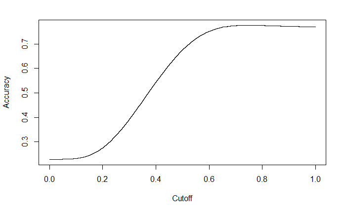

```r
# using ROCR for metrics at cutoff
lr.prediction = prediction(lr.pconf, aidaTest$Failed)
# acc at cutoff
lr.acc = performance(lr.prediction, "acc"); plot(lr.acc)
```

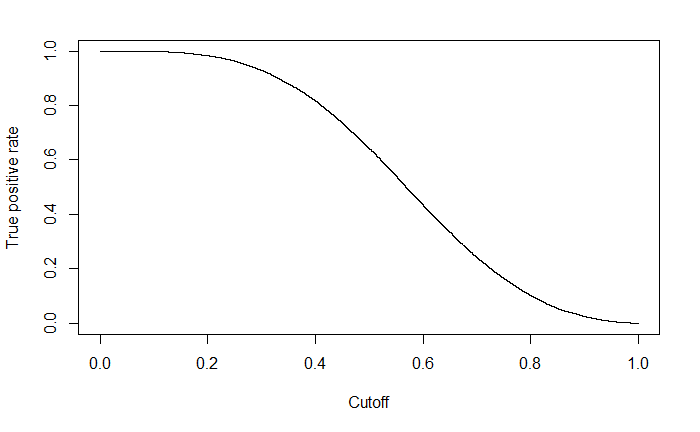

```r
# tpr (recall) at cutoff
lr.tpr = performance(lr.prediction, "tpr"); plot(lr.tpr)
```

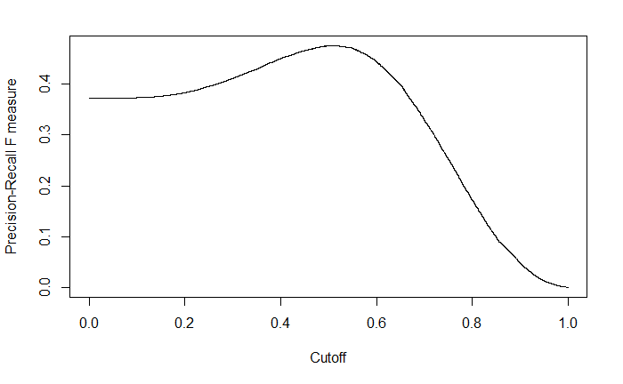

```r
# f1 at cutoff
lr.f1 = performance(lr.prediction, "f"); plot(lr.f1)
```

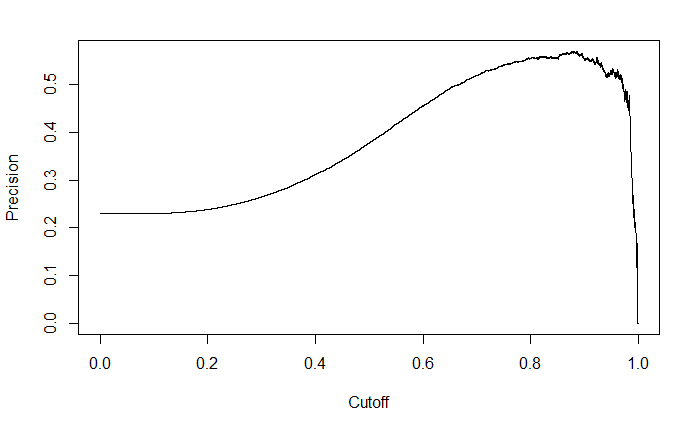

```r
# precision at cutoff
lr.prec = performance(lr.prediction, "prec"); plot(lr.prec)
```

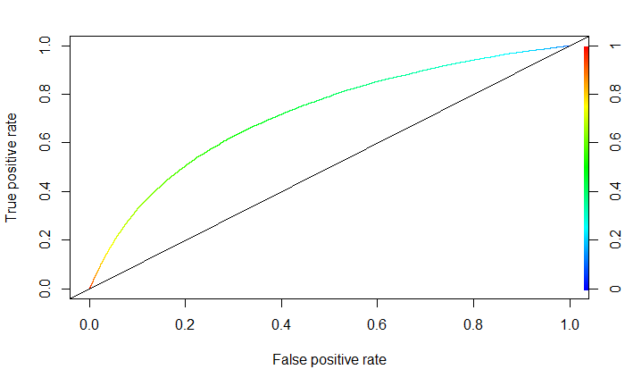

```r
# roc curve
lr.roc = performance(lr.prediction, "tpr", "fpr")
plot(lr.roc, colorize=T); abline(a=0, b= 1)
```

```r
# AUC: performance returns an object whose members (called 'slots') are accessed with '@'
o = performance(lr.prediction, "auc")
o@y.values[[1]]
```

```
[1] 0.717423
```

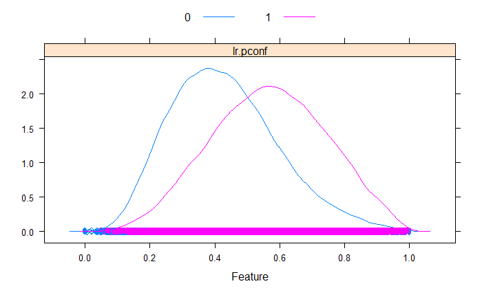

```r
featurePlot(x=data.frame(lr.pconf), y=aidaTest$Failed, plot='density', auto.key = list(columns = 2))
```

Logistic Regression usando cross validation con custom summary function, gli attributi usati sono quelli risultati dalla procedure glmStepAIC il training set usato è quello su cui si è applicato random undersampling

```r
lev = c("class0", "class1")
down.aidaTrain$Failed = factor(down.aidaTrain$Failed); levels(down.aidaTrain$Failed) = lev
aidaTest$Failed = factor(aidaTest$Failed); levels(aidaTest$Failed) = lev

# repeated cross validation
rcv = trainControl(method="repeatedcv",
                   repeats=5, number=10,
                   classProbs = TRUE,
                   savePredictions = TRUE, #per poi poter valutare le performance anche sul training set
                   summaryFunction = twoClassSummary)

lr2.fit = train(best.formula, data = down.aidaTrain,
                method = "glm", trControl=rcv,
                metric="ROC",
                family=binomial(logit))
lr2.fit
```

```
Generalized Linear Model

100476 samples
    23 predictor
     2 classes: 'class0', 'class1'

No pre-processing
Resampling: Cross-Validated (10 fold, repeated 5 times)
Summary of sample sizes: 90429, 90428, 90429, 90429, 90428, 90428, ...
Resampling results:

  ROC        Sens       Spec
  0.7208388  0.6835464  0.6496239
```

```r
# details over 5x10 folds
lr2.folds = lr2.fit$resample[['ROC']]
mean(lr2.folds) # reported is mean performance
```

```
[1] 0.7208388
```

```r
# predicted confidence on validation set
lr.pred = predict(lr2.fit, newdata = aidaTest, type="raw")
lr.prob = predict(lr2.fit, newdata = aidaTest, type="prob") # as predict_proba in scikit-learn
lr.pconf = lr.prob[,2]
# built-in metrics
confusionMatrix(lr.pred, aidaTest$Failed, positive="class1", mode = "prec_recall")
```

```
Confusion Matrix and Statistics

          Reference
Prediction class0 class1
    class0  49441   7647
    class1  22863  13840

               Accuracy : 0.6747
                 95% CI : (0.6717, 0.6777)
    No Information Rate : 0.7709
    P-Value [Acc > NIR] : 1

                  Kappa : 0.2626

 Mcnemar's Test P-Value : <2e-16

              Precision : 0.3771
                 Recall : 0.6441
                     F1 : 0.4757
             Prevalence : 0.2291
         Detection Rate : 0.1476
   Detection Prevalence : 0.3913
      Balanced Accuracy : 0.6640

       'Positive' Class : class1
```

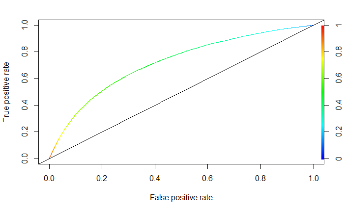

```r
lr.prediction = prediction(lr.pconf, aidaTest$Failed)


#lr.prediction = prediction(lr2.fit$pred$class1, lr2.fit$pred$obs) #Per valutare la ROC curve sui dati di training

lr.roc = performance(lr.prediction, "tpr", "fpr")
plot(lr.roc, colorize=T); abline(a=0, b= 1)
```

Random forest per fare un confronto delle performance ottenute con logistic regression Si fa il training sullo stesso training set per poi poter fare un confronto tra i folds delle rispettive cross validation

```r
set.seed(42)
tunegrid = expand.grid(.mtry=sqrt(ncol(down.aidaTrain)))
rf.fit = train(Failed~., data = down.aidaTrain,
               method = "rf", trControl=rcv,
               metric="ROC", tuneGrid=tunegrid,
               ntree=15)
rf.fit
```

```
Random Forest

100476 samples
    23 predictor
     2 classes: 'class0', 'class1'

No pre-processing
Resampling: Cross-Validated (10 fold, repeated 5 times)
Summary of sample sizes: 90429, 90428, 90429, 90428, 90429, 90429, ...
Resampling results:

  ROC        Sens       Spec
  0.7803851  0.6993989  0.7297623

Tuning parameter 'mtry' was held constant at a value of 4.898979
```

```r
rf.fit$resample # details over 5x10 folds
```

| ROC | Sens | Spec | Resample |
| --- | --- | --- | --- |
| 0.7818716 | 0.7105316 | 0.7255175 | Fold01.Rep1 |
| 0.7849544 | 0.7048169 | 0.7340764 | Fold02.Rep1 |
| 0.7707739 | 0.6994427 | 0.7139160 | Fold03.Rep1 |
| 0.7878149 | 0.7022293 | 0.7332803 | Fold04.Rep1 |
| 0.7775016 | 0.7012341 | 0.7306391 | Fold05.Rep1 |
| 0.7881476 | 0.7009755 | 0.7354697 | Fold06.Rep1 |
| 0.7785443 | 0.6912818 | 0.7362659 | Fold07.Rep1 |
| 0.7785003 | 0.6936704 | 0.7370621 | Fold08.Rep1 |
| 0.7824986 | 0.7010350 | 0.7289013 | Fold09.Rep1 |
| 0.7803877 | 0.7036226 | 0.7289013 | Fold10.Rep1 |

[output cut: 40 more lines]

```r
rf.folds = rf.fit$resample[['ROC']]
t.test(rf.folds) # confidence interval
```

```
    One Sample t-test

data:  rf.folds
t = 1177.8, df = 49, p-value < 2.2e-16
alternative hypothesis: true mean is not equal to 0
95 percent confidence interval:
 0.7790536 0.7817166
sample estimates:
mean of x
0.7803851
```

```r
# details over 5x10 folds
rf.folds = rf.fit$resample[['ROC']]
mean(rf.folds) # reported is mean performance
```

```
[1] 0.7803851
```

Confronto tra i valori di AUC dei folds di random forest e logistic regression

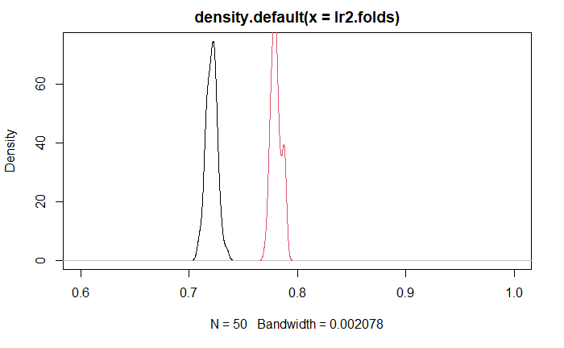

```r
library(BSDA)

plot(density(lr2.folds),xlim=c(0.6,1))
lines(density(rf.folds),col=2)
```

Test di normalità delle due distribuzioni con Shapiro test

```r
# test of normality
shapiro.test(lr2.folds)
```

```
    Shapiro-Wilk normality test

data:  lr2.folds
W = 0.99246, p-value = 0.9865
```

```r
shapiro.test(rf.folds)
```

```
    Shapiro-Wilk normality test

data:  rf.folds
W = 0.96061, p-value = 0.09428
```

F-test per verificare se le due distribuzioni hanno la stessa varianza Non si può rifiutare l’ipotesi nulla e assumendo che le distribuzioni abbiano la stessa varianza si procede con t-test

```r
var(lr2.folds); var(rf.folds)
```

```
[1] 2.54967e-05
[1] 2.195086e-05
```

```r
# F-test
var.test(lr2.folds, rf.folds)
```

```
    F test to compare two variances

data:  lr2.folds and rf.folds
F = 1.1615, num df = 49, denom df = 49, p-value = 0.6022
alternative hypothesis: true ratio of variances is not equal to 1
95 percent confidence interval:
 0.6591435 2.0468438
sample estimates:
ratio of variances
          1.161535
```

```r
t.test(lr2.folds, rf.folds, var.equal=T)
```

```
    Two Sample t-test

data:  lr2.folds and rf.folds
t = -61.127, df = 98, p-value < 2.2e-16
alternative hypothesis: true difference in means is not equal to 0
95 percent confidence interval:
 -0.06147939 -0.05761309
sample estimates:
mean of x mean of y
0.7208388 0.7803851
```

Wilcoxon test (distribuzioni con stessa forma ma con posizioni shifate)

```r
wilcox.test(lr2.folds, rf.folds)
```

[output not shown]

Bootstrap t.test

```r
library(MKinfer)
boot.t.test(lr2.folds, rf.folds, R=1000)
```

```
    Bootstrapped Welch Two Sample t-test

data:  lr2.folds and rf.folds
bootstrapped p-value < 2.2e-16
95 percent bootstrap percentile confidence interval:
 -0.06142159 -0.05770469

Results without bootstrap:
t = -61.127, df = 97.456, p-value < 2.2e-16
alternative hypothesis: true difference in means is not equal to 0
95 percent confidence interval:
 -0.06147953 -0.05761295
sample estimates:
mean of x mean of y
0.7208388 0.7803851
```

Paired test, dovrebbe produrre i migliori risultati in quanto le misurazioni delle due distribuzioni si riferiscono agli stessi fold della cross validation

```r
t.test(lr2.folds, rf.folds, paired=TRUE) # or
```

```
    Paired t-test

data:  lr2.folds and rf.folds
t = -62.123, df = 49, p-value < 2.2e-16
alternative hypothesis: true difference in means is not equal to 0
95 percent confidence interval:
 -0.06147246 -0.05762002
sample estimates:
mean of the differences
            -0.05954624
```

```r
t.test(lr2.folds - rf.folds, mu=0)
```

```
    One Sample t-test

data:  lr2.folds - rf.folds
t = -62.123, df = 49, p-value < 2.2e-16
alternative hypothesis: true mean is not equal to 0
95 percent confidence interval:
 -0.06147246 -0.05762002
sample estimates:
  mean of x
-0.05954624
```